# StatGenet2017

## 6.3 Clustering and heatmap

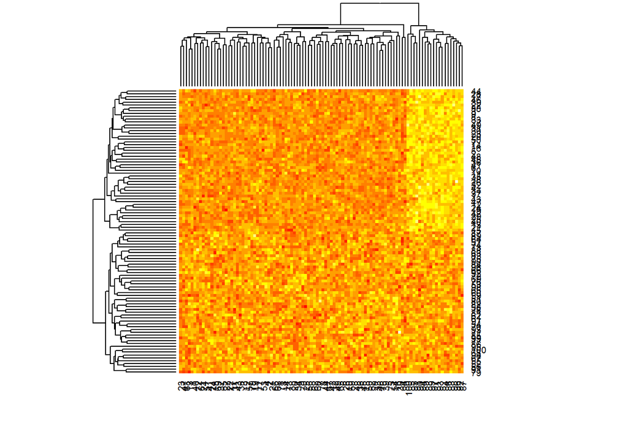

```r
n.genes <- 10^2
frac.assoc <- 0.2
n.assoc <- n.genes*frac.assoc
n.non.assoc <- n.genes-n.assoc

n1 <- n2 <- 50
d1.non.assoc <- matrix(rnorm(n1*n.non.assoc),nrow=n1)
d2.non.assoc <- matrix(rnorm(n2*n.non.assoc),nrow=n2)

d1.assoc <- matrix(rnorm(n1*n.assoc,2),nrow=n1)
d2.assoc <- matrix(rnorm(n2*n.assoc,0),nrow=n2)

d1 <- cbind(d1.non.assoc,d1.assoc)
d2 <- cbind(d2.non.assoc,d2.assoc)

d.all <- rbind(d1,d2)
heatmap(d.all)
```

#### 6.3.0.1 Distance, similarlity

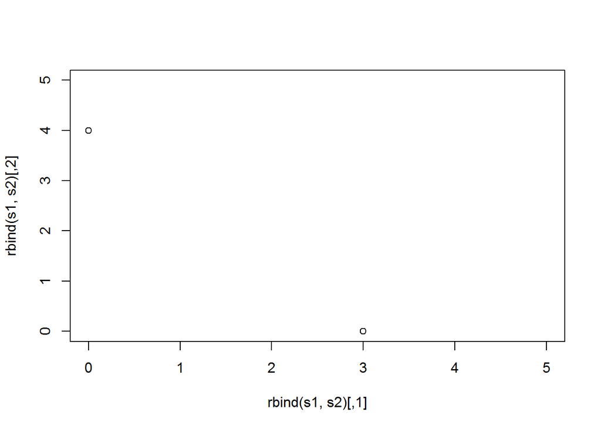

```r
s1 <- c(3,0)
s2 <- c(0,4)
plot(rbind(s1,s2),xlim = c(0,5),ylim=c(0,5))
```

Distance

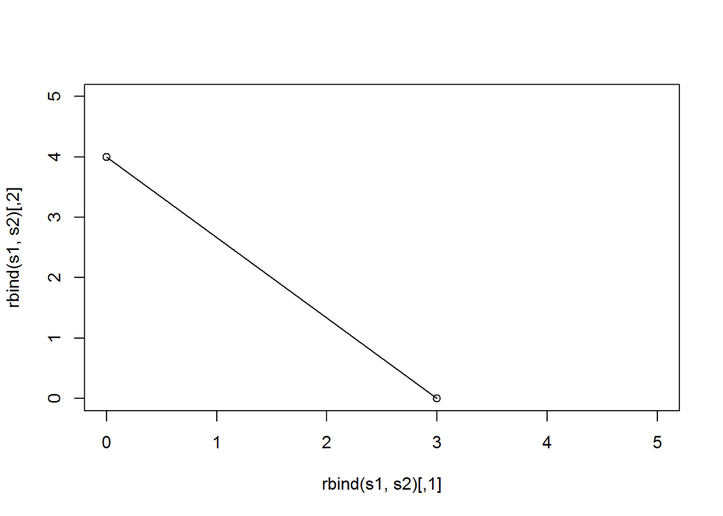

```r
plot(rbind(s1,s2),xlim = c(0,5),ylim=c(0,5))
segments(s1[1],s1[2],s2[1],s2[2])
```

```r
sqrt(sum((s1-s2)^2))
```

```
## [1] 5
```

Angle measures similarlity as well.

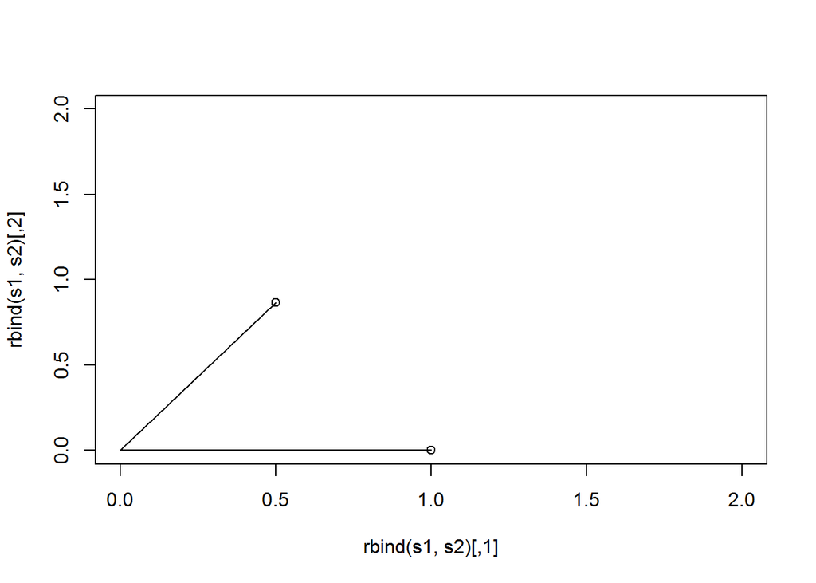

```r
s1 <- c(1,0)
s2 <- c(1/2,sqrt(3)/2)
plot(rbind(s1,s2),xlim = c(0,2),ylim=c(0,2))
segments(0,0,s1[1],s1[2])
segments(0,0,s2[1],s2[2])
```

```r
x <- sum(s1*s2)/sqrt(sum(s1^2)*sum(s2^2))
theta <- acos(x)
theta/pi
```

```
## [1] 0.3333333
```

```r
s2. <- c(cos(theta),sin(theta))
s2.
```

```
## [1] 0.5000000 0.8660254
```

```r
s2
```

```
## [1] 0.5000000 0.8660254
```

#### 6.3.0.2 Distance matrix and trees

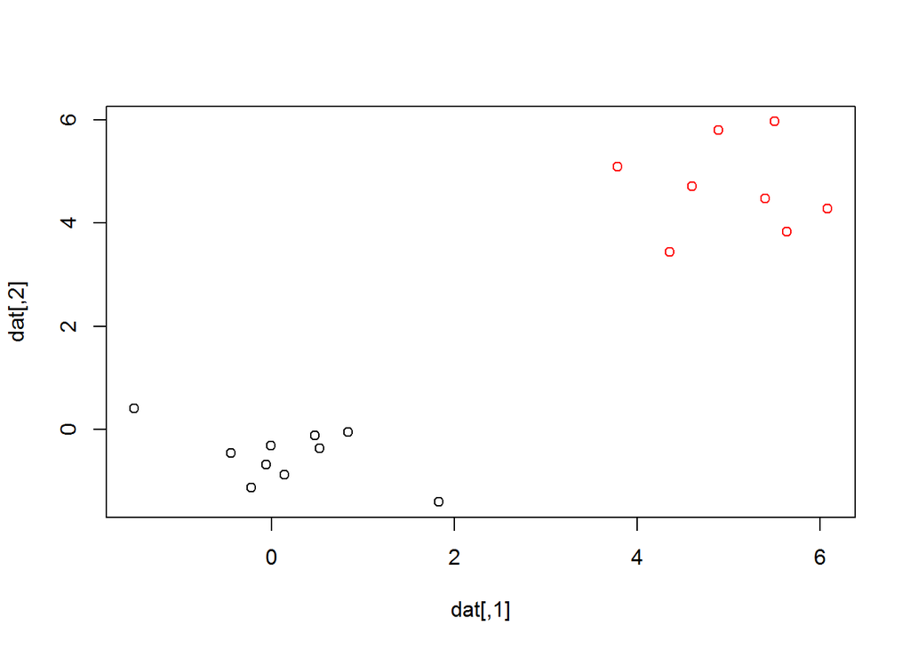

```r
n1 <- 10
d <- 2
cl1 <- matrix(rnorm(n1*d),ncol=d)
n2 <- 8
cl2 <- matrix(rnorm(n2*d),ncol=d) + 5

dat <- rbind(cl1,cl2)
plot(dat,col=c(rep(1,n1),rep(2,n2)))
```

Distance matirx.

Red: close

Yellow : Apart

```r
dm <- as.matrix(dist(dat))
dm
```

```
##            1        2         3         4         5         6         7
## 1  0.0000000 2.176103 0.2437706 0.5382086 1.0734595 0.6705780 0.9746198
## 2  2.1761028 0.000000 2.0525881 1.6654055 2.0044631 1.8180703 1.3728771
## 3  0.2437706 2.052588 0.0000000 0.5208909 1.2239160 0.7763934 0.9758782
## 4  0.5382086 1.665406 0.5208909 0.0000000 0.8398613 0.3743847 0.4555610
## 5  1.0734595 2.004463 1.2239160 0.8398613 0.0000000 0.4707682 0.7073055
## 6  0.6705780 1.818070 0.7763934 0.3743847 0.4707682 0.0000000 0.4485565
## 7  0.9746198 1.372877 0.9758782 0.4555610 0.7073055 0.4485565 0.0000000
## 8  0.4339648 2.387833 0.3664839 0.8833813 1.5073990 1.0945806 1.3389247
## 9  0.6501069 2.097741 0.8312128 0.5884145 0.4393461 0.2816766 0.7254732
## 10 1.6699290 3.799747 1.8661815 2.1375611 2.0720304 2.0205195 2.4632198
## 11 8.0582809 8.950540 7.9057003 8.3661141 9.1260666 8.6804519 8.7598459
## 12 7.5622943 8.373380 7.4003018 7.8485484 8.6236941 8.1717709 8.2319508
## 13 5.3991393 6.601614 5.2726105 5.7624240 6.4725170 6.0473422 6.1845397
## 14 6.6130126 7.921482 6.5059827 7.0086890 7.6811397 7.2736882 7.4419855
```

[output cut: 42 more lines]

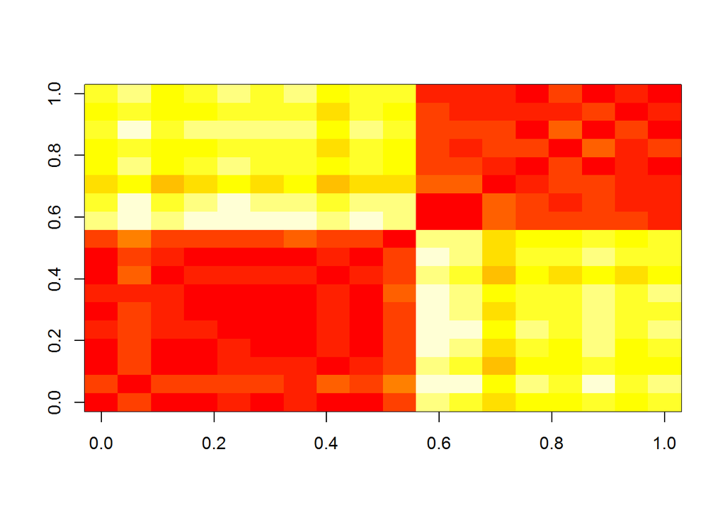

```r
image(dm)
```

Clustering

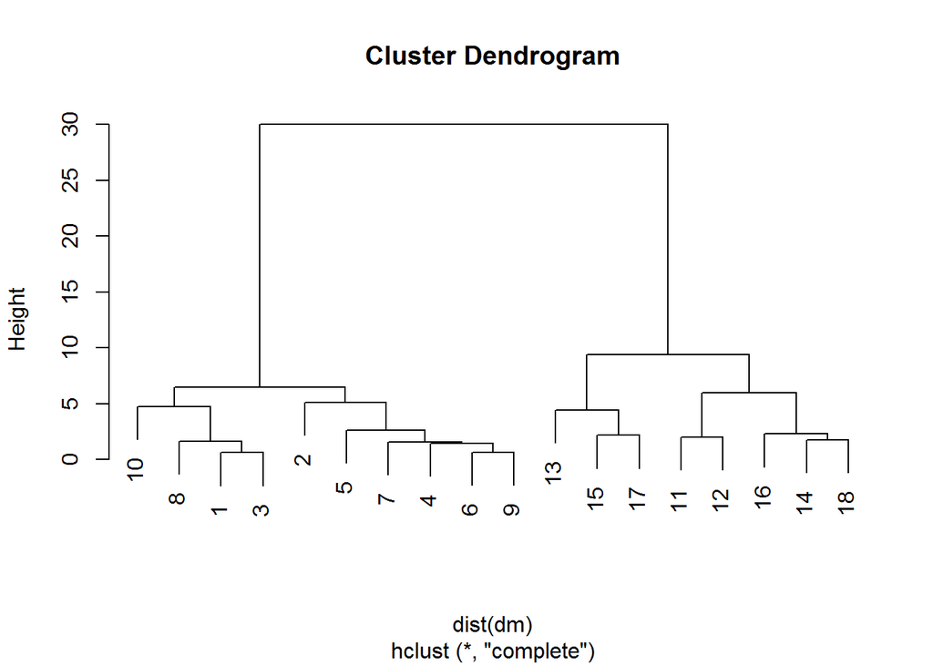

```r
plot(hclust(dist(dm)))
```

#### 6.3.0.3 Tree generation

There are multiple ways to generate cluster trees.

Neighbor joining method is one of them. It is good to understande what the tree shapes and length of edges mean.

When there are three items to be clustered, distance values are maintained in the tree.

```r
# install.packages("ape")
library(ape)
```

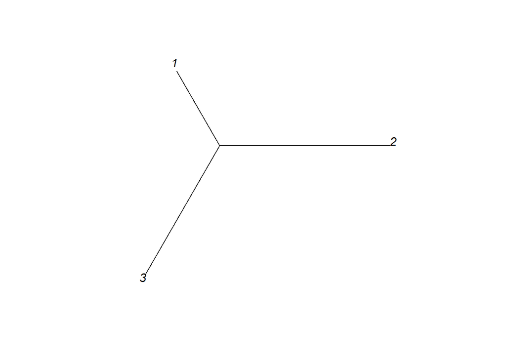

```r
n.tips <- 3
k <- 2 # dimension
d <- matrix(rnorm(n.tips*k),ncol=k)
dm <- as.matrix(dist(d))
cl <- nj(dm)
plot(cl,type="unroot")
```

```r
cl$edge
```

```
##      [,1] [,2]
## [1,]    4    3
## [2,]    4    2
## [3,]    4    1
```

```r
cl$edge.length
```

```
## [1] 1.0224303 1.1639646 0.5894491
```

```r
dm
```

```
##          1        2        3
## 1 0.000000 1.753414 1.611879
## 2 1.753414 0.000000 2.186395
## 3 1.611879 2.186395 0.000000
```

```
[Exercise]
Check the IDs of tip nodes and the node inserted and calculate distances amon the tips in the tree yourself.
```

The distance along the tree from a tip to another tip is the same with the value in the distance matrix.

You can check it by making a graph object with edges and edge length information.

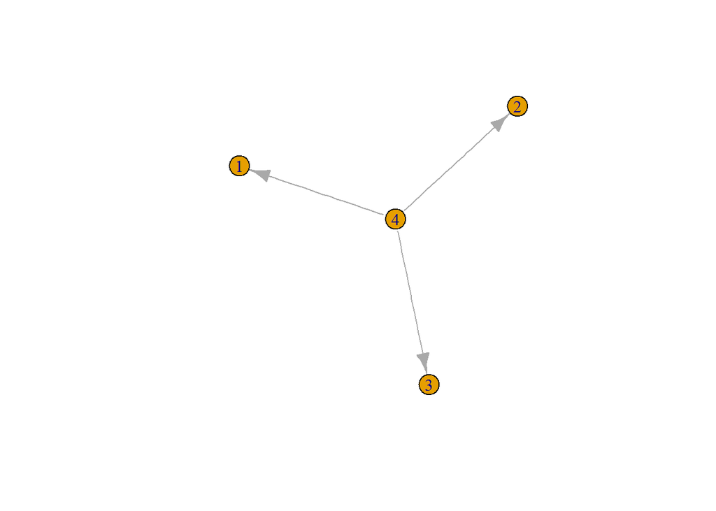

```r
library(igraph)
g <- graph.edgelist(cl$edge)
E(g)$weight <- cl$edge.length
plot(g)
```

```r
dm.from.g <- distances(g)
dm.from.g
```

```
##           [,1]     [,2]     [,3]      [,4]
## [1,] 0.0000000 1.753414 1.611879 0.5894491
## [2,] 1.7534137 0.000000 2.186395 1.1639646
## [3,] 1.6118794 2.186395 0.000000 1.0224303
## [4,] 0.5894491 1.163965 1.022430 0.0000000
```

```r
dm.from.g[1:3,1:3]
```

```
##          [,1]     [,2]     [,3]
## [1,] 0.000000 1.753414 1.611879
## [2,] 1.753414 0.000000 2.186395
## [3,] 1.611879 2.186395 0.000000
```

```r
dm
```

```
##          1        2        3
## 1 0.000000 1.753414 1.611879
## 2 1.753414 0.000000 2.186395
## 3 1.611879 2.186395 0.000000
```

```r
dm.from.g[1:3,1:3] - dm
```

```
##               1             2            3
## 1  0.000000e+00 -2.220446e-16 2.220446e-16
## 2 -2.220446e-16  0.000000e+00 0.000000e+00
## 3  2.220446e-16  0.000000e+00 0.000000e+00
```

The tree and its edge lenght represent distance values of all pairs.

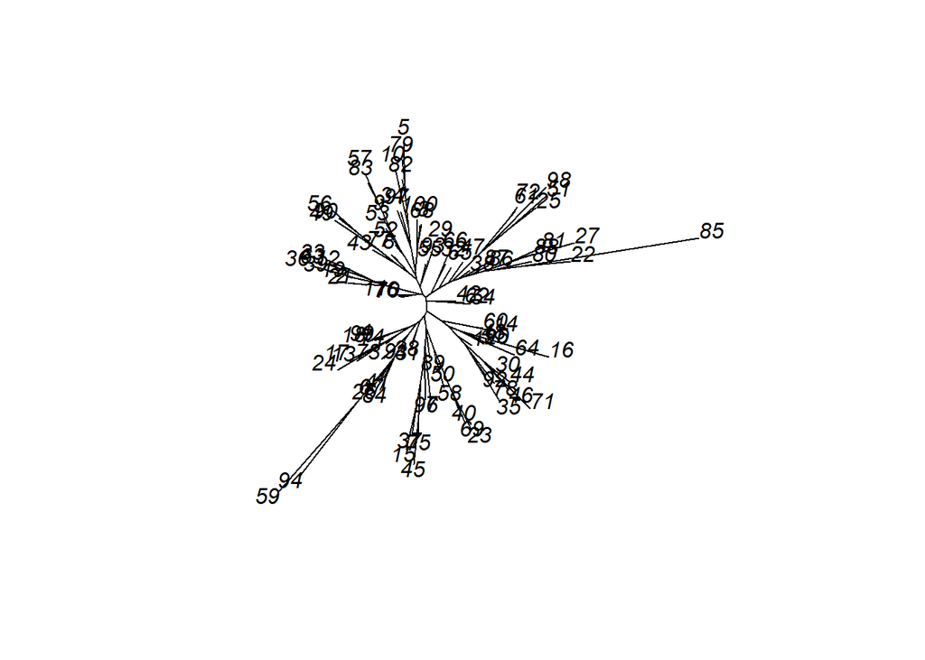

```r
n.tips <- 100
k <- 4
d <- matrix(rnorm(n.tips*k),ncol=k)
dm <- as.matrix(dist(d))
cl <- nj(dm)
plot(cl,type="unroot")
```

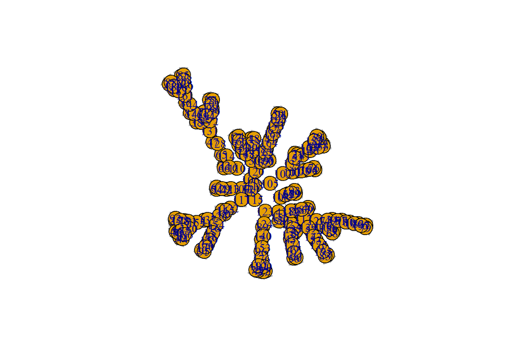

```r
#cl$edge
#cl$edge.length
g <- graph.edgelist(cl$edge)
E(g)$weight <- cl$edge.length
plot(g)
```

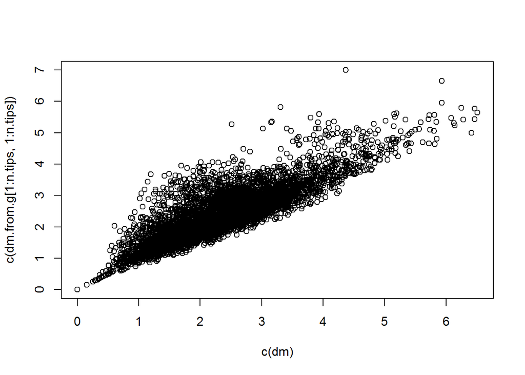

```r
dm.from.g <- distances(g)
plot(c(dm),c(dm.from.g[1:n.tips,1:n.tips]))
```

```r
#range(dm.from.g[1:n.tips,1:n.tips] - dm)
```

#### 6.3.0.4 Heatmap ~ clustering samples and clustering genes

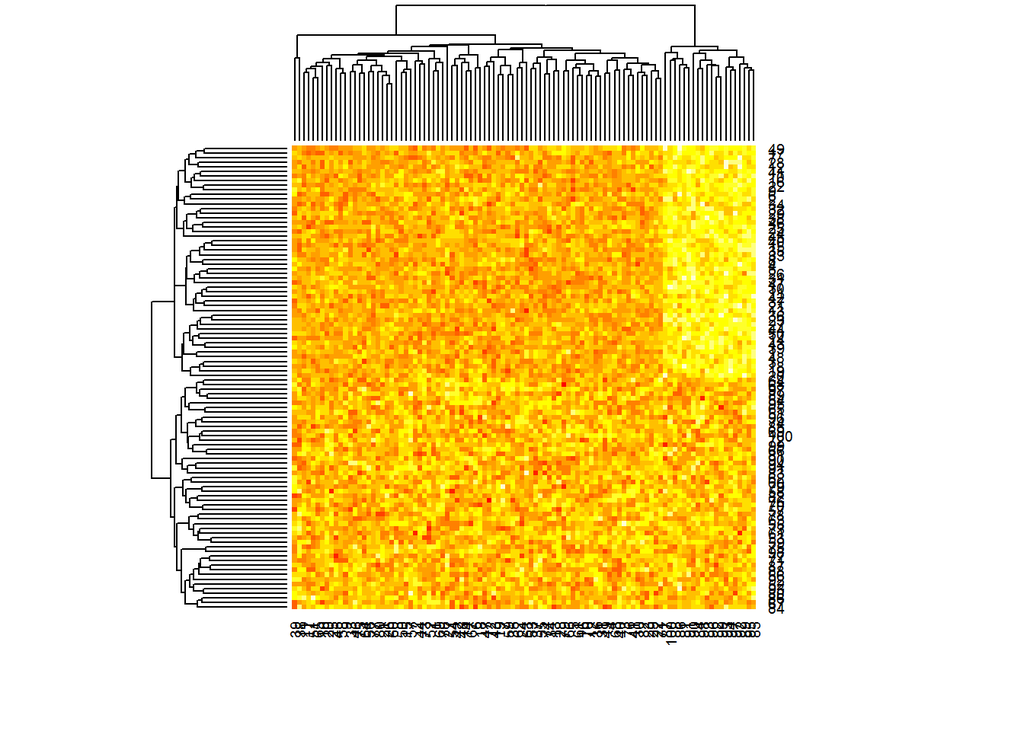

```r
n.genes <- 10^2
frac.assoc <- 0.2
n.assoc <- n.genes*frac.assoc
n.non.assoc <- n.genes-n.assoc

n1 <- n2 <- 50
d1.non.assoc <- matrix(rnorm(n1*n.non.assoc),nrow=n1)
d2.non.assoc <- matrix(rnorm(n2*n.non.assoc),nrow=n2)

d1.assoc <- matrix(rnorm(n1*n.assoc,2),nrow=n1)
d2.assoc <- matrix(rnorm(n2*n.assoc,0),nrow=n2)

d1 <- cbind(d1.non.assoc,d1.assoc)
d2 <- cbind(d2.non.assoc,d2.assoc)

d.all <- rbind(d1,d2)
heatmap(d.all)
```

d.all:

rows : samples

columns : genes

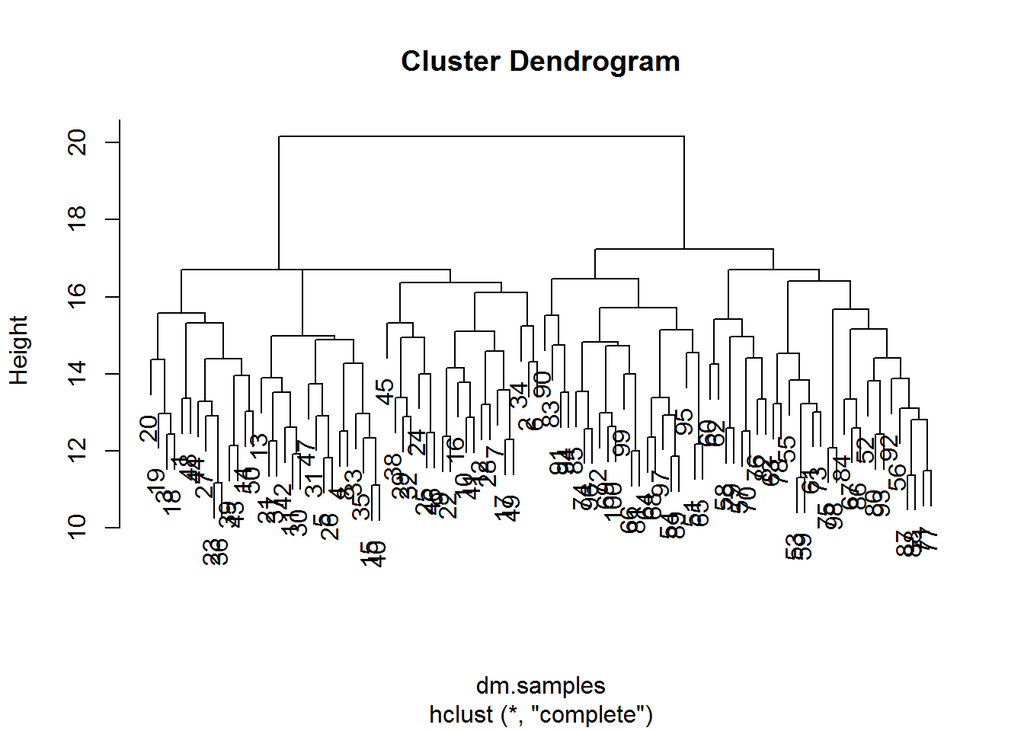

```r
dm.samples <- dist(d.all)
dm.genes <- dist(t(d.all))

plot(hclust(dm.samples))
```

[figure not shown]

```
[Exercise]
Use (1-cos(theta)), where theta is an angle between two vectors as dissimilarity measure (definition of distance) and make a function that makes a distance matrix.
```

```r
plot(hclust(dm.genes))
```

#### 6.3.0.5 Non-supervised

The clusters were generated just based on the data set. This means the clustering procedure is non-supervised, or no-true-answer-information.

## 6.4 Supervised clustering

### 6.4.1 Data simulation

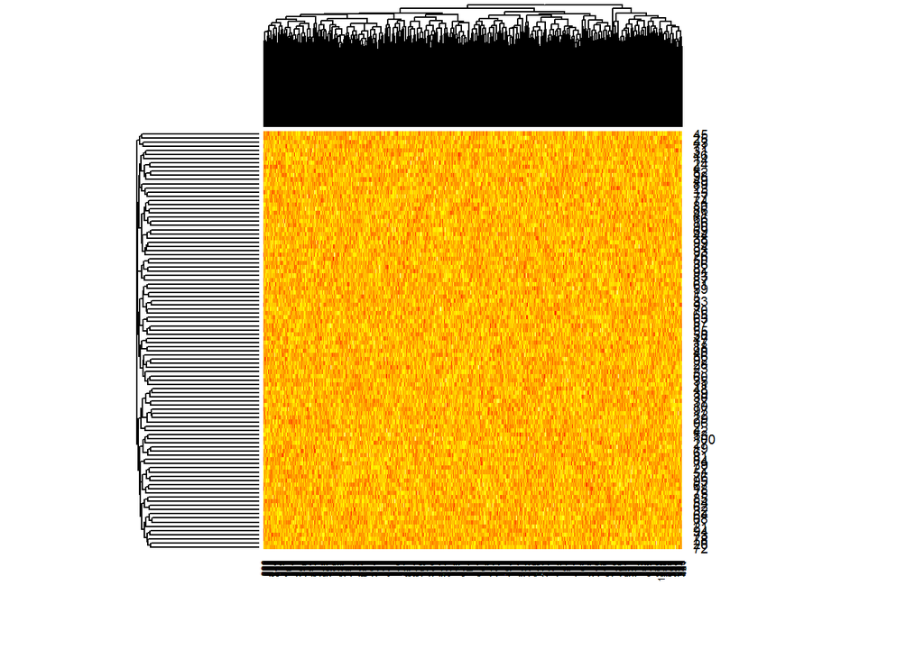

```r
n.genes <- 10^3
frac.assoc <- 0.5
n.assoc <- n.genes*frac.assoc
n.non.assoc <- n.genes-n.assoc

n1 <- n2 <- 50
d1.non.assoc <- matrix(rnorm(n1*n.non.assoc),nrow=n1)
d2.non.assoc <- matrix(rnorm(n2*n.non.assoc),nrow=n2)

# Associated genes have various effect size
d1.assoc <- matrix(rnorm(n1*n.assoc,2),nrow=n1)
for(i in 1:n.assoc){
  d1.assoc[,i] <- rnorm(n1,rnorm(1,0,0.1))
}
d2.assoc <- matrix(rnorm(n2*n.assoc,0),nrow=n2)

d1 <- cbind(d1.non.assoc,d1.assoc)
d2 <- cbind(d2.non.assoc,d2.assoc)

d.all <- rbind(d1,d2)
heatmap(d.all)
```

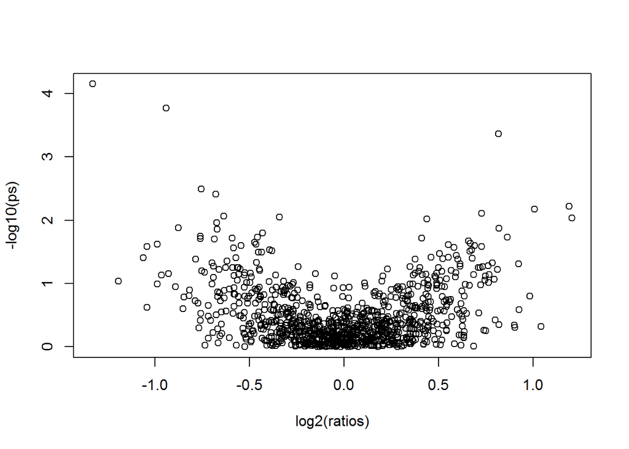

```r
# Gene expression levels are assumed to be in log-normal distribution.
ps <- ratios <- rep(0,n.gene)
for(i in 1:n.genes){
  ps[i] <- t.test(d1[,i],d2[,i])$p.value
  ratios[i] <- mean(exp(d1[,i]))/mean(exp(d2[,i]))
}

plot(log2(ratios),-log10(ps))
```

### 6.4.2 Supervised model fitting

We want to predict phenotypes with gene expression data.

We have phenotype data, that are “answers”.

We can generate models with “answers”, supervised.

Rank genes based on the ratio.

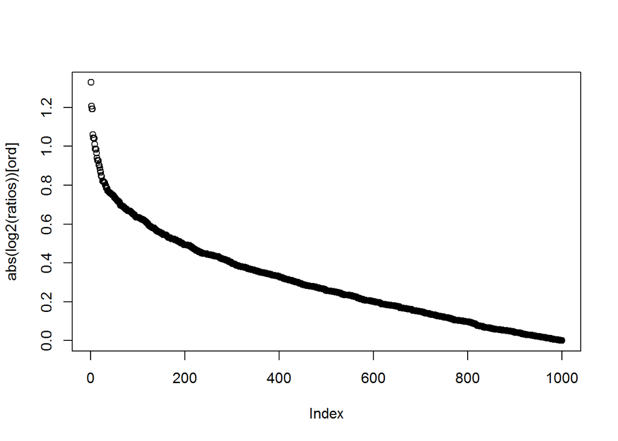

```r
ord <- order(abs(log2(ratios)),decreasing=TRUE)
plot(abs(log2(ratios))[ord])
```

From the top of the absolute ratio values to the bottom, genes are to be added to logistic regression model.

```r
phenotype <- c(rep(0,n2),rep(1,n2))
n.factor <- 30
predicted <- matrix(0,n1+n2,n.factor)
for(i in 1:n.factor){
  log.lm.out <- glm(phenotype~d.all[,ord[1:i]],family = binomial(link='logit'))
  predicted[,i] <- predict(log.lm.out)
}
```

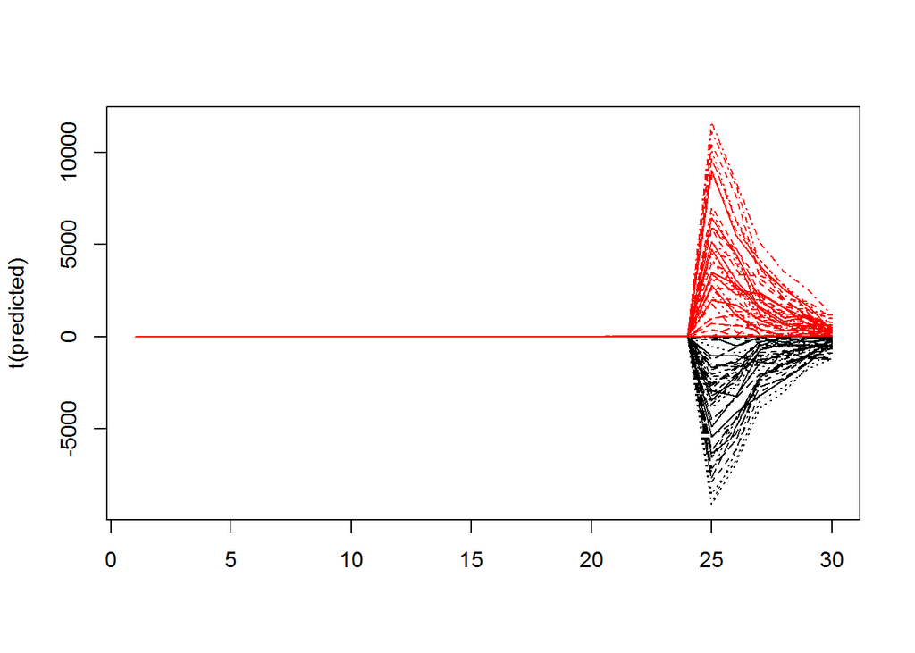

```r
matplot(t(predicted),type="l",col=c(rep(1,n1),rep(2,n2)))
```

With the increase in the number of genes, the segregation performance becomes better.

### 6.4.3 Over-fitting

```r
n.genes <- 10^3
frac.assoc <- 0.5
n.assoc <- n.genes*frac.assoc
n.non.assoc <- n.genes-n.assoc

n1 <- n2 <- 50
N1 <- n1 * 2
N2 <- n2 * 2
d1.non.assoc <- matrix(rnorm(N1*n.non.assoc),nrow=N1)
d2.non.assoc <- matrix(rnorm(N2*n.non.assoc),nrow=N2)

# Associated genes have various effect size
d1.assoc <- matrix(rnorm(N1*n.assoc,2),nrow=N1)
for(i in 1:n.assoc){
  d1.assoc[,i] <- rnorm(N1,rnorm(1,0,0.1))
}
d2.assoc <- matrix(rnorm(N2*n.assoc,0),nrow=N2)

D1 <- cbind(d1.non.assoc,d1.assoc)
D2 <- cbind(d2.non.assoc,d2.assoc)

D.all <- rbind(d1,d2)

d1.training <- D1[1:n1,]
d2.training <- D2[1:n2,]

d1.test <- D1[(1+n1):N1,]
d2.test <- D2[(1+n2):N2,]
d.training <- rbind(d1.training,d2.training)
d.test <- rbind(d1.test,d2.test)
```

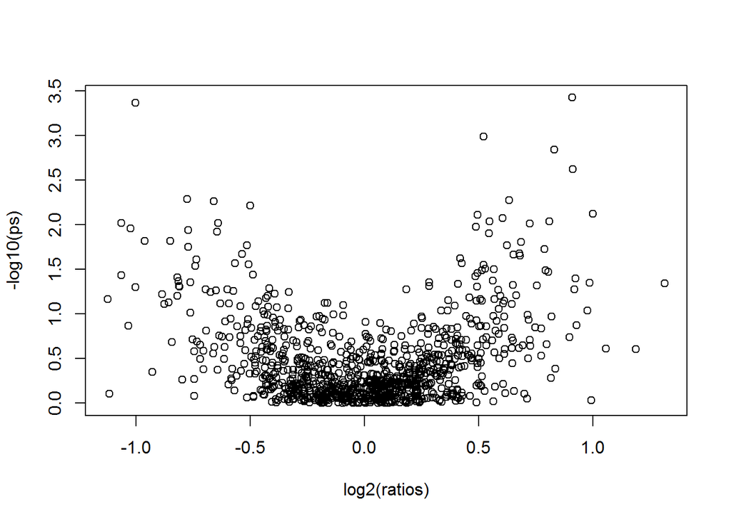

```r
# Gene expression levels are assumed to be in log-normal distribution.
ps <- ratios <- rep(0,n.gene)
for(i in 1:n.genes){
  ps[i] <- t.test(d1.training[,i],d2.training[,i])$p.value
  ratios[i] <- mean(exp(d1.training[,i]))/mean(exp(d2.training[,i]))
}

plot(log2(ratios),-log10(ps))
```

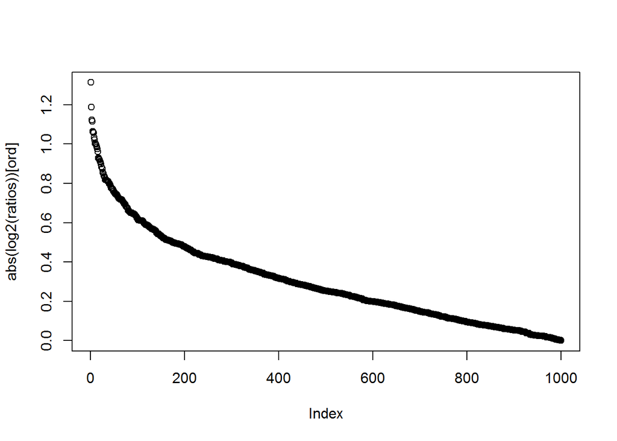

```r
ord <- order(abs(log2(ratios)),decreasing=TRUE)
plot(abs(log2(ratios))[ord])
```

```r
phenotype <- c(rep(0,n2),rep(1,n2))
n.factor <- 30
predicted.training <- predicted.test <- matrix(0,n1+n2,n.factor)
for(i in 1:n.factor){
  log.lm.out <- glm(phenotype~d.training[,ord[1:i]],family = binomial(link='logit'))
  predicted.training[,i] <- apply(log.lm.out$coefficients[-1] * t(d.training[,ord[1:i]]),2,sum)
  predicted.test[,i] <- apply(log.lm.out$coefficients[-1] * t(d.test[,ord[1:i]]),2,sum)
}
```

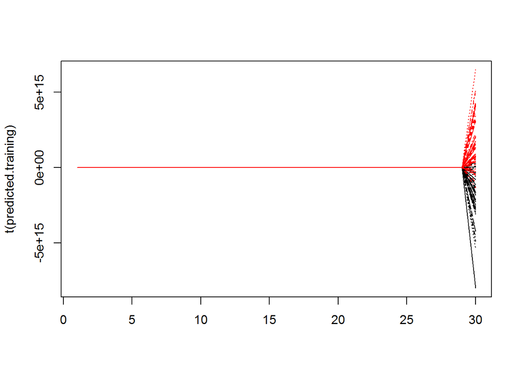

```r
matplot(t(predicted.training),type="l",col=c(rep(1,n1),rep(2,n2)))
```

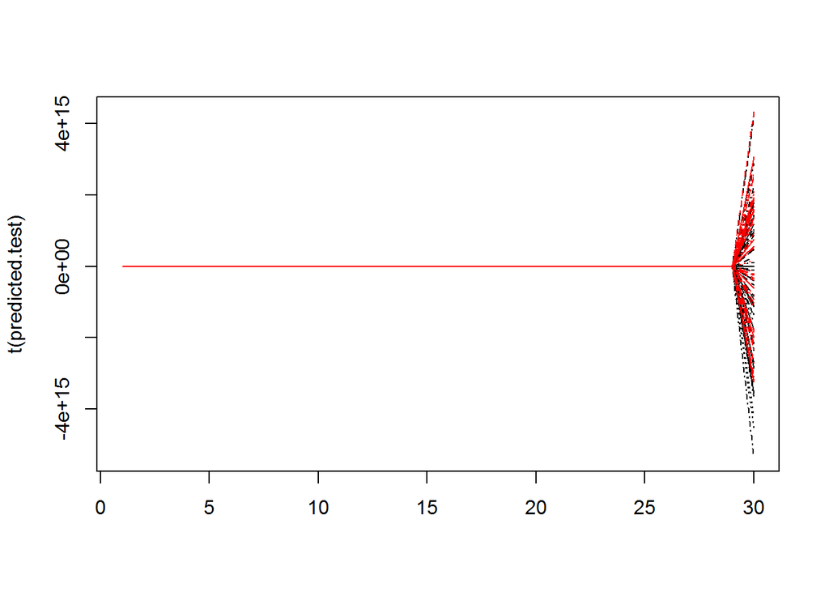

```r
matplot(t(predicted.test),type="l",col=c(rep(1,n1),rep(2,n2)))
```

With the increase in the number of genes included the model, the classification of samples used to generate the model becomes better.

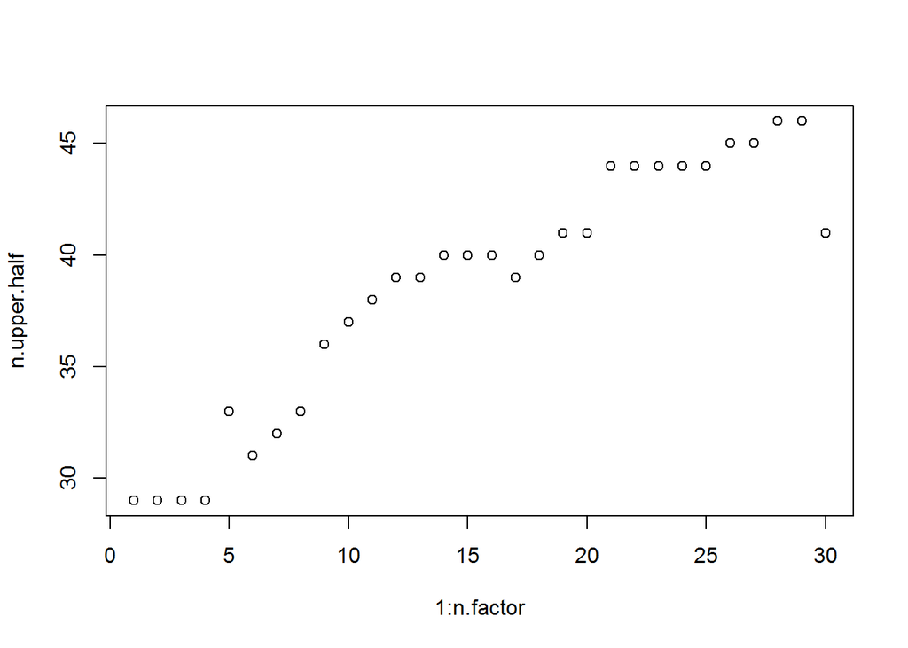

```r
n.upper.half <- rep(0,n.factor)
for(i in 1:n.factor){
  tmp.pred0 <- predicted.training[,i]
  tmp.pred <- predicted.training[1:n1,i]
  n.upper.half[i] <- length(which(tmp.pred<quantile(tmp.pred0,0.5)))
}
plot(1:n.factor,n.upper.half)
```

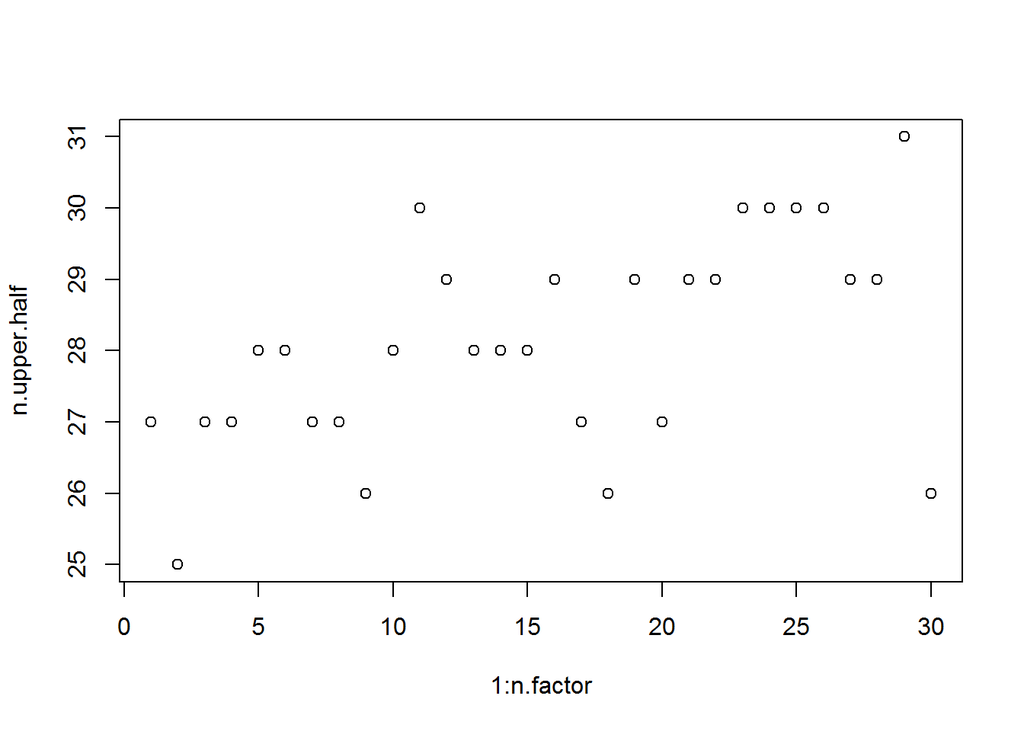

```r
n.upper.half <- rep(0,n.factor)
for(i in 1:n.factor){
  tmp.pred0 <- predicted.test[,i]
  tmp.pred <- predicted.test[1:n1,i]
  n.upper.half[i] <- length(which(tmp.pred<quantile(tmp.pred0,0.5)))
}
plot(1:n.factor,n.upper.half)
```

The modeld became too good to the particular samples of training but they were deviated from the truth.

It is called overfitting.

### 6.4.4 How to avoid overfitting

#### 6.4.4.1 Training and testing

Generate models with a fraction of samples (training samples).

Check the models’ performance with the rest of the samples (test samples).

The good model(s) should segregate the test samples well.

#### 6.4.4.2 Cross-validation methods

Generation of models are better with more samples.

We can separate the whole samples into training and testing in many ways by randomly assigning them to two subsets.

For each separation, the “best” gene set is identified. The final selection of “predictive gene set” should be the consensus of many attempts.

https://www.r-bloggers.com/cross-validation-for-predictive-analytics-using-r/

```
[Exercise]
Run the examples of cross-valiadtion function mentioned in the r-blogger article.
```

## 6.5 Validation for its clinical use

http://link.springer.com/article/10.1007%2Fs10549-010-0814-2

```
[Exercise]
Summarize how the paper validated the utility of the set of genes.
```